# Synthetic Methods

paul.ruizpinto@qut.edu.au

2025-11-26

## **Summary**

This document prepares and organises the data for a literature review on synthetic data generation methods in sports science.

## **Aim**

To collect, clean, and combine reference data from several research databases, and prepare a summary for review and visualisation.

## **Approach**

The review integrates references from five major databases:

- `IEEE`
- `QUT library`
- `Science Direct`
- `Springer Nature`
- `Web of Science`

All `.ris` and `.csv` files were imported from the databases into a single structure (title, year, abstract, `data/literature/ris/.ris & .csv`)

Duplicate records were identified based on titles and removed, keeping only the first occurrence to ensure one unique record per publication.

The dataset `(n = 224)` was reviewed using the `revtools::screen_abstracts()` shiny interface for manual selection of studies using abstracts `(n = 28)`.

`22` files were selected after reading methodologies in `NVivo`.

## **Results**

- Bibliographic data from `22` files were combined into one table `(data/literature/literatureReview.xlsx)`.
- An `infographic` was produced showing research methods and their categories.

## **Conclusion**

It was found that synthetic data can be mainly generated using GAN-based, simulation-based, or statistical approaches, and their comparison is summarised in the table below.

| Criterion | GAN-based | Simulation-based | Statistical |
| --- | --- | --- | --- |
| Realism | ⭐⭐⭐⭐ | ⭐⭐⭐⭐ | ⭐⭐ |
| Privacy | ⭐⭐⭐ | ⭐⭐⭐⭐⭐ | ⭐⭐⭐⭐ |
| Data variety | ⭐⭐⭐⭐ | ⭐⭐⭐⭐ | ⭐⭐ |
| Technical complexity | High | Very High | Medium |
| Best for | Time-series, video, or image data | Physical / injury simulation | Variable-level control |

## **Data Preparation**

```r
list.files("data/literature/ris/")
```

```
## [1] "ieee.ris"           "qut.ris"            "scienceDirect.ris"
## [4] "springerNature.csv" "webofScience.ris"   "webofScience_.ris"
```

```r
# Error in webofS, remove empty line
wos <- readLines("data/literature/ris/webofScience.ris")
wos <- wos[wos != ""]
writeLines(wos, "data/literature/ris/webofScience_.ris")
```

```r
# Load files
ieee <- read_bibliography("data/literature/ris/ieee.ris")
qut <- read_bibliography("data/literature/ris/qut.ris")
scienceDirect <- read_bibliography("data/literature/ris/scienceDirect.ris")
springerNature <- read_bibliography("data/literature/ris/springerNature.csv")
webofScience <- read_bibliography("data/literature/ris/webofScience_.ris")
head(ieee[,1:5])
```

|  | label | type | title | journal | pages |
| --- | --- | --- | --- | --- | --- |
| 1 | J..Chen_2019_20IECoonCoVianPaReWo.C | CONF | Sports Camera Calibration via Synthetic Data | 2019 IEEE/CVF Conference on Computer Vision and Pattern Recognition Workshops (CVPRW) | 2497-2504 |
| 2 | T..Baumgartner_2023_20IECoonCoVianPaReWo.C | CONF | Monocular 3D Human Pose Estimation for Sports Broadcasts using Partial Sports Field Registration | 2023 IEEE/CVF Conference on Computer Vision and Pattern Recognition Workshops (CVPRW) | 5109-5118 |
| 3 | A..Hong_2024_2012InCoonInSyanCoTe.I | CONF | Data Augmentation and Neural Network for American Football Formation Recognition | 2024 12th International Conference on Information Systems and Computing Technology (ISCTech) | 1-5 |
| 4 | S..Shah_2020_204tInCoonElCoanAeTe.I | CONF | Machine learning based Synthetic Data Generation using Iterative Regression Analysis | 2020 4th International Conference on Electronics, Communication and Aerospace Technology (ICECA) | 1093-1100 |
| 5 | R..Hori_2021_20IEInCoonImPr.I | CONF | Silhouette-Based Synthetic Data Generation For 3D Human Pose Estimation With A Single Wrist-Mounted 360Â° Camera | 2021 IEEE International Conference on Image Processing (ICIP) | 1304-1308 |
| 6 | M..Tran_2025_I2.2IICoASaSP. | CONF | A Domain Adaptation Framework for Speech Recognition Systems with Only Synthetic data | ICASSP 2025 - 2025 IEEE International Conference on Acoustics, Speech and Signal Processing (ICASSP) | 1-5 |

```r
# Rename columns in springerNature
names(springerNature)[names(springerNature) == "item_title"] <- "title"
names(springerNature)[names(springerNature) == "publication_year"] <- "year"

## Add a missing column and filled in with "NA"
springerNature$abstract <-NA

colnames(springerNature)
```

```
##  [1] "title"             "publication_title" "book_series_title"
##  [4] "journal_volume"    "journal_issue"     "item_doi"
##  [7] "author"            "year"              "URL"
## [10] "content_type"      "abstract"
```

```r
# Merge files
merge <- function(...){
  list <- list(...)

  data <- lapply(list, function(df) {
    for (col in c("title", "year", "abstract")) {
      if (!col %in% names(df)) {
        df[[col]] <- NA
      }
    }
    df[, c("title", "year", "abstract")]
  })

  combined<- do.call(rbind, data)
  row.names(combined) <- NULL
  return(combined)
}

bibliography <- merge(ieee, qut, scienceDirect, springerNature, webofScience)

dim(bibliography)
```

```
## [1] 258   3
```

```r
# Title preparition
bibliography$titleLower<-tolower(bibliography$title)
bibliography$titleLower<-strip(bibliography$titleLower, apostrophe.remove = TRUE)
```

```r
# Check for duplicates
unique(bibliography$titleLower[duplicated(bibliography$titleLower)])
```

```
##  [1] "silhouettebased d human pose estimation using a single wristmounted â camera"
##  [2] "calibrate interactive analysis of probabilistic model output"
##  [3] "patchemg fewshot emg signal generation with diffusion models for data augmentation to improve classification performance"
##  [4] "kganbased semisupervised domain adapted human activity recognition"
##  [5] "task scheduling in threedimensional spatial crowdsourcing a social welfare perspective"
##  [6] "improving pagerank using sports results modeling"
##  [7] "soccer computer graphics meets sports analytics for soccer event recognition"
##  [8] "âœplay by playâ\u009d a dataset of handball and basketball game situations in a standardized space"
##  [9] "machine learningbased smart irrigation controller for runoff minimization in turfgrass irrigation"
## [10] "advancements in basketball action recognition datasets methods explainability and synthetic data applications"
## [11] "improvement of accuracy of underperforming classifier in decision making using discrete memoryless channel model and particle swarm optimization"
## [12] "synthetic data for sharing and exploration in highperformance sport considerations for application"
## [13] "book of abstracts esmrmb online th annual scientific meeting october"
## [14] "ecr book of abstracts"
## [15] "synthetic data as a strategy to resolve data privacy and confidentiality concerns in the sport sciences practical examples and an r shiny application"
## [16] "a synthetic datadriven machine learning approach for athlete performance attenuation prediction"
## [17] "understanding accelerationbased load metrics from concepts to implementation"
## [18] "implementing multiple imputation for missing data in longitudinal studies when models are not feasible an example using the random hot deck approach"
## [19] "crossmodal selfattention mechanism for controlling robot volleyball motion"
## [20] "artificial intelligence in the selection of topperforming athletes for team sports a proofofconcept predictive modeling study"
## [21] "jersey number detection using synthetic data in a lowdata regime"
## [22] "a novel explainable artificial intelligence framework using knockoffs techniques with applications to sports analytics"
## [23] "analysis of player tracking data extracted from football match feed"
## [24] "semantic representation and comparative analysis of physical activity sensor observations using mox sensor in real and synthetic datasets a proofofconceptstudy"
## [25] "d human pose data augmentation using generative adversarial networks for roboticassisted movement quality assessment"
## [26] "dynamic ranking with the btl model a nearest neighbor based rank centrality method"
```

```r
# Remove duplicated titles, keeping the first unique entry
bibliography_ <- bibliography[!duplicated(bibliography$titleLower), ]

# Check that duplicates are gone
any(duplicated(bibliography_$titleLower))
```

```
## [1] FALSE
```

```r
# Use shiny app to filter based on Abstract
# screen_abstracts(bibliography_)
```

## **Bibliography**

The 22 files were downloaded and imported to Nvivo. Manually coding and creating a matrix.

```r
# Match number of selected references 28 with numbers of pdfs
files <- list.files("data/literature/reference/", pattern = "\\.pdf$", full.names = TRUE)
cat("Total PDF files found:", length(files), "\n")
```

```
## Total PDF files found: 22
```

## **Infographic**

```r
infographic <- read_excel("data/literature/literatureReview/literatureReview.xlsx",
                          sheet = "infographic")
infographic
```

| group | description | examples | generation.approach.model |
| --- | --- | --- | --- |
| GAN-based models | Generate realistic synthetic data using two competing neural networks one creates data, the other judges realism until the synthetic samples resemble the real ones. | Creating synthetic motion capture, wearable-sensor, or video data for training and performance analysis. | GAN augmentation/DCGAN/TimeGAN/ Conditional GAN/Kolmogorov–Arnold GAN (KGAN)/Silhouette-based GAN/GAN + SVM + DenseNet hybrid.2D.3D synthetic rendering + GAN |
| Simulation-based methods | Use computer-generated environments, physics engines, or rule-based models to imitate athlete behavior or physical events when real data collection is limited or unsafe. | Simulating cycling sessions, football gameplay, biomechanical impacts, or training loads. | Game-engine simulation/Unreal Engine 5 simulation/Finite Element simulation/Hybrid ML simulation/Rule-based generation (TSM metric)/Vision-based tracking & JSON normalization |
| Statistical / Regression-based methods | Produce new samples by reproducing statistical patterns or learned variable relationships using mathematical models rather than neural networks. | Generating realistic athlete-performance tables, expanding small datasets, or privacy-preserving data sharing. | CART (synthpop R)/Iterative Regression Analysis/Tabular Variational Autoencoder (TVAE)/Oversampling & Regression Synthesis |

```r
# Prepare Data for threefieldplot
infographic_ <- infographic %>%
  separate_rows(generation.approach.model, sep = "/") %>%
  mutate(generation.approach.model = trimws(generation.approach.model))

# Wrap text to multiple lines for readability
wrap_text <- function(x, width = 25) str_wrap(x, width = width)

infographic_ <- infographic_ %>%
  mutate(
    generation.approach.model = wrap_text(generation.approach.model, 20),
    group = wrap_text(group, 25),
    description = wrap_text(description, 30),
    examples = wrap_text(examples, 30)
  )

infographic_
```

| group | description | examples | generation.approach.model |
| --- | --- | --- | --- |
| GAN-based models | Generate realistic synthetic\ndata using two competing\nneural networks one creates\ndata, the other judges realism\nuntil the synthetic samples\nresemble the real ones. | Creating synthetic motion\ncapture, wearable-sensor, or\nvideo data for training and\nperformance analysis. | GAN augmentation |
| GAN-based models | Generate realistic synthetic\ndata using two competing\nneural networks one creates\ndata, the other judges realism\nuntil the synthetic samples\nresemble the real ones. | Creating synthetic motion\ncapture, wearable-sensor, or\nvideo data for training and\nperformance analysis. | DCGAN |
| GAN-based models | Generate realistic synthetic\ndata using two competing\nneural networks one creates\ndata, the other judges realism\nuntil the synthetic samples\nresemble the real ones. | Creating synthetic motion\ncapture, wearable-sensor, or\nvideo data for training and\nperformance analysis. | TimeGAN |
| GAN-based models | Generate realistic synthetic\ndata using two competing\nneural networks one creates\ndata, the other judges realism\nuntil the synthetic samples\nresemble the real ones. | Creating synthetic motion\ncapture, wearable-sensor, or\nvideo data for training and\nperformance analysis. | Conditional GAN |
| GAN-based models | Generate realistic synthetic\ndata using two competing\nneural networks one creates\ndata, the other judges realism\nuntil the synthetic samples\nresemble the real ones. | Creating synthetic motion\ncapture, wearable-sensor, or\nvideo data for training and\nperformance analysis. | Kolmogorov–Arnold\nGAN (KGAN) |
| GAN-based models | Generate realistic synthetic\ndata using two competing\nneural networks one creates\ndata, the other judges realism\nuntil the synthetic samples\nresemble the real ones. | Creating synthetic motion\ncapture, wearable-sensor, or\nvideo data for training and\nperformance analysis. | Silhouette-based GAN |
| GAN-based models | Generate realistic synthetic\ndata using two competing\nneural networks one creates\ndata, the other judges realism\nuntil the synthetic samples\nresemble the real ones. | Creating synthetic motion\ncapture, wearable-sensor, or\nvideo data for training and\nperformance analysis. | GAN + SVM + DenseNet\nhybrid.2D.3D\nsynthetic rendering\n+ GAN |
| Simulation-based methods | Use computer-generated\nenvironments, physics engines,\nor rule-based models to\nimitate athlete behavior or\nphysical events when real\ndata collection is limited or\nunsafe. | Simulating cycling\nsessions, football gameplay,\nbiomechanical impacts, or\ntraining loads. | Game-engine\nsimulation |
| Simulation-based methods | Use computer-generated\nenvironments, physics engines,\nor rule-based models to\nimitate athlete behavior or\nphysical events when real\ndata collection is limited or\nunsafe. | Simulating cycling\nsessions, football gameplay,\nbiomechanical impacts, or\ntraining loads. | Unreal Engine 5\nsimulation |
| Simulation-based methods | Use computer-generated\nenvironments, physics engines,\nor rule-based models to\nimitate athlete behavior or\nphysical events when real\ndata collection is limited or\nunsafe. | Simulating cycling\nsessions, football gameplay,\nbiomechanical impacts, or\ntraining loads. | Finite Element\nsimulation |

[output cut: 7 more lines]

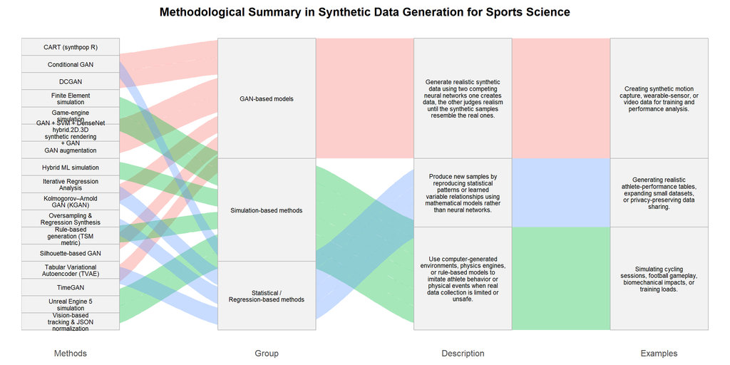

```r
# Plot
ggplot(infographic_,
       aes(axis1 = generation.approach.model,
           axis2 = group,
           axis3 = description,
           axis4 = examples)) +
  geom_alluvium(aes(fill = group), width = 0.05, alpha = 0.35) +
  geom_stratum(width = 0.5, fill = "grey95", color = "grey70") +
  geom_text(stat = "stratum",
            aes(label = after_stat(stratum)),
            size = 3,
            lineheight = 0.9,
            color = "black") +
  scale_x_discrete(limits = c("Methods", "Group", "Description", "Examples"),
                   expand = c(.05, .05)) +
  theme_minimal(base_size = 15) +
  theme(
    axis.title = element_blank(),
    axis.text.y = element_blank(),
    panel.grid = element_blank(),
    legend.position = "none",
    plot.margin = margin(10, 30, 10, 30),
    plot.title = element_text(face = "bold", size = 16, hjust = 0.5),
    plot.background = element_rect(fill = "white", color = NA)
  ) +
  ggtitle("Methodological Summary in Synthetic Data Generation for Sports Science")
```